# Supervised learning competition

Authors

Osaro Orebor 1168827

Máté Csikós-Nagy 4395565

Fani Profiti 1240390

Yara Yachnyk 4913329

Niels Wagenaar 3133998

# Data description

The dataset represents the characteristics of the secondary school students and additional information about their family background with their specific profile information, such as age, education of male or female partent etc.

It has a selection of categorical (factor) (such as school, sex, adress..) and continuous (numeric) quantitative variables such as age, as well as boolean yes or no variables.

The split between males and females is relatively equal (Female: 173, Male: 143). The score range volatiles from -2.71 to 2.23, which shows that the variable is standardized, implying the formula (raw_score-mean/sd) was implied for better interpretation of students’ results.

##Score distribution

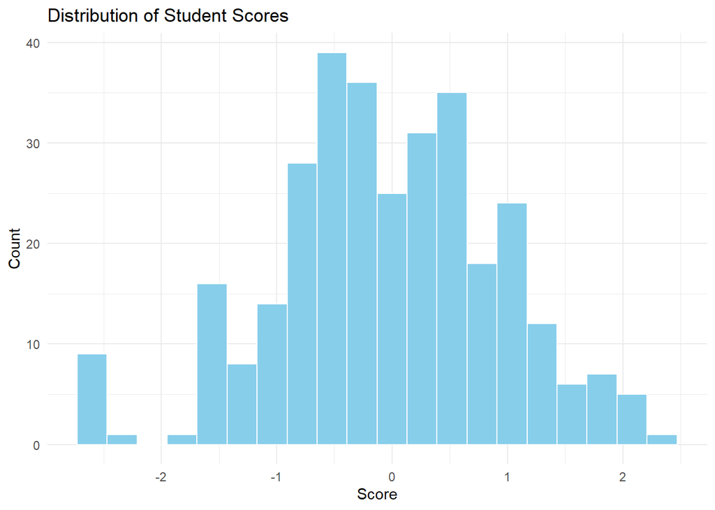

```r
ggplot(train, aes(x = score)) +
  geom_histogram(fill = "skyblue", color = "white", bins = 20) +
  theme_minimal() +
  labs(title = "Distribution of Student Scores",
       x = "Score", y = "Count")
```

```r
# Summary statistics for numerical variables
train %>%
  select(where(is.numeric)) %>%
  summary()
```

```
      age             Medu            Fedu         traveltime
 Min.   :15.00   Min.   :0.000   Min.   :0.000   Min.   :1.000
 1st Qu.:16.00   1st Qu.:2.000   1st Qu.:2.000   1st Qu.:1.000
 Median :17.00   Median :3.000   Median :2.000   Median :1.000
 Mean   :16.75   Mean   :2.737   Mean   :2.503   Mean   :1.453
 3rd Qu.:18.00   3rd Qu.:4.000   3rd Qu.:3.000   3rd Qu.:2.000
 Max.   :22.00   Max.   :4.000   Max.   :4.000   Max.   :4.000
   studytime        failures          famrel         freetime
 Min.   :1.000   Min.   :0.0000   Min.   :1.000   Min.   :1.000
 1st Qu.:1.000   1st Qu.:0.0000   1st Qu.:4.000   1st Qu.:3.000
 Median :2.000   Median :0.0000   Median :4.000   Median :3.000
 Mean   :2.035   Mean   :0.3703   Mean   :3.934   Mean   :3.218
 3rd Qu.:2.000   3rd Qu.:0.0000   3rd Qu.:5.000   3rd Qu.:4.000
 Max.   :4.000   Max.   :3.0000   Max.   :5.000   Max.   :5.000
     goout            Dalc            Walc           health
 Min.   :1.000   Min.   :1.000   Min.   :1.000   Min.   :1.000
 1st Qu.:2.000   1st Qu.:1.000   1st Qu.:1.000   1st Qu.:3.000
 Median :3.000   Median :1.000   Median :2.000   Median :3.500
 Mean   :3.066   Mean   :1.468   Mean   :2.288   Mean   :3.465
 3rd Qu.:4.000   3rd Qu.:2.000   3rd Qu.:3.000   3rd Qu.:5.000
 Max.   :5.000   Max.   :5.000   Max.   :5.000   Max.   :5.000
    absences          score
 Min.   : 0.000   Min.   :-2.70532
 1st Qu.: 0.000   1st Qu.:-0.63494
 Median : 4.000   Median :-0.02769
 Mean   : 5.718   Mean   :-0.01620
 3rd Qu.: 8.000   3rd Qu.: 0.64029
 Max.   :75.000   Max.   : 2.23458
```

Since we make prediction on score, in test set we do not include this variable and train the dataset based on the other characteristics to then try to predict for those test observations.

```r
# Preview the data
glimpse(train)
```

```
Rows: 316
Columns: 31
$ school     <fct> GP, GP, GP, GP, GP, GP, GP, GP, GP, GP, MS, GP, GP, GP, GP,…
$ sex        <fct> F, F, M, M, F, F, M, F, F, M, M, F, F, M, F, M, M, M, M, M,…
$ age        <dbl> 18, 17, 17, 18, 16, 15, 15, 15, 16, 15, 18, 15, 17, 16, 15,…
$ address    <fct> U, U, U, R, U, R, U, U, U, U, U, U, R, U, U, U, U, U, U, U,…
$ famsize    <fct> GT3, GT3, GT3, GT3, GT3, LE3, LE3, GT3, GT3, GT3, GT3, GT3,…
$ Pstatus    <fct> T, T, T, T, T, T, T, T, T, T, T, T, T, T, A, T, T, T, T, T,…
$ Medu       <dbl> 3, 3, 2, 4, 1, 2, 3, 4, 3, 2, 4, 1, 3, 3, 3, 3, 4, 2, 1, 4,…
$ Fedu       <dbl> 2, 4, 3, 3, 3, 2, 3, 4, 3, 3, 4, 2, 1, 3, 3, 3, 2, 1, 2, 2,…
$ Mjob       <fct> other, services, other, teacher, at_home, health, other, se…
$ Fjob       <fct> services, other, other, services, services, services, other…
$ reason     <fct> other, course, course, course, home, reputation, course, co…
$ guardian   <fct> mother, mother, father, mother, mother, mother, mother, mot…
$ traveltime <dbl> 1, 1, 2, 1, 1, 2, 1, 1, 1, 1, 1, 1, 2, 1, 1, 1, 1, 1, 1, 1,…
```

[output cut: 18 more lines]

## Correlation table

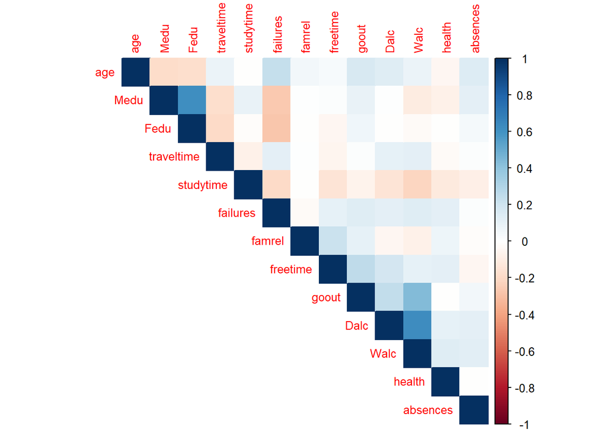

```r
# Compute correlation matrix for numeric variables
num_vars <- train %>% select(where(is.numeric)) %>% select(-score)
cor_mat <- cor(num_vars, use = "pairwise.complete.obs")

corrplot(cor_mat, method = "color", type = "upper", tl.cex = 0.8)
```

```r
# Correlation of each numeric variable with score
correlations <- train %>%
  select(where(is.numeric)) %>%
  cor(use = "pairwise.complete.obs") %>%
  as.data.frame() %>%
  rownames_to_column("Variable") %>%
  select(Variable, score) %>%
  arrange(desc(abs(score)))

head(correlations, 10)
```

| Variable | score |
| --- | --- |
| score | 1.0000000 |
| failures | -0.4059704 |
| Medu | 0.2345784 |
| Fedu | 0.1929621 |
| goout | -0.1790390 |
| age | -0.1737671 |
| studytime | 0.1235700 |
| health | -0.0996427 |
| Walc | -0.0928007 |
| traveltime | -0.0845962 |

### Checking for & handling missing values

First, we check the dataset for missing values that could affect the result.

```r
train %>% summarise(across(everything(), ~sum(is.na(.)))) %>%
  pivot_longer(everything(), names_to = "variable", values_to = "missing_count") %>%
  arrange(desc(missing_count))
```

| variable | missing_count |
| --- | --- |
| school | 0 |
| sex | 0 |
| age | 0 |
| address | 0 |
| famsize | 0 |
| Pstatus | 0 |
| Medu | 0 |
| Fedu | 0 |
| Mjob | 0 |
| Fjob | 0 |
| reason | 0 |
| guardian | 0 |
| traveltime | 0 |
| studytime | 0 |
| failures | 0 |
| schoolsup | 0 |
| famsup | 0 |
| paid | 0 |
| activities | 0 |
| nursery | 0 |
| higher | 0 |
| internet | 0 |
| romantic | 0 |
| famrel | 0 |
| freetime | 0 |
| goout | 0 |
| Dalc | 0 |
| Walc | 0 |
| health | 0 |
| absences | 0 |
| score | 0 |

Fortunately, based on the output, we have no missing values in the dataset.

### Converting categorical variables to factors

Next, we need to convert categorical variables which are currently stored as text to factors to use for training our models.

```r
train_clean <- train %>%
  mutate(across(where(is.character), as.factor))
```

### Converting yes/no variables to boolean values

Similarly, yes or no values will be converted to boolean values.

```r
# Identify yes/no columns automatically and assign them boolean values
train_clean <- train_clean %>%
  mutate(across(
    where(~ (is.character(.) || is.factor(.)) && all(tolower(unique(.)) %in% c("yes", "no"))),
    ~ tolower(as.character(.)) == "yes"
  ))
```

### Normalizing numerical values

For k-nearest neighbors and neural nets it is essential to normalize numerical values to the same scale, otherwise variables with a different range of values would have a much bigger effect on the model than others.

The numerical variables which are a score from 1-5 (or 1-4) are not continous are scaled using min-max scaling (because we can’t assume normal distribution there).

```r
# scaling 1-5 scores (5 will be 1 and 1 will be scaled to 0)
train_norm <- train_clean %>% mutate(across(c("famrel","freetime","goout","Dalc","Walc", "health"), ~ (. - 1) / 4))

# scaling 1-4 scores (4 will be 1 and 1 will be scaled to 0)
train_norm <- train_norm %>% mutate(across(c(Medu, Fedu), ~ . / 4))
```

Some numerical variables are encoding bins (like `studytime` or `traveltime`). In this case, to keep the distances more preserved, we assign the mid-point of the bins and normalize those (for instance the value 2 in studytime means 2 to 5 hours of studying - in this case we replace 2 with 3.5 and normalize that).

```r
# scaling bin-type variables to their midpoints (traveltime and studytime)

# travel time in minutes with approximate midpoints
train_norm <- train_norm %>%
  mutate(traveltime = case_when(
    traveltime == 1 ~ 7.5,
    traveltime == 2 ~ 22.5,
    traveltime == 3 ~ 45,
    traveltime == 4 ~ 75
  ))

# studytime in hours with approximate midpoints
train_norm <- train_norm %>%
  mutate(studytime = case_when(
    studytime == 1 ~ 1,
    studytime == 2 ~ 3.5,
    studytime == 3 ~ 7.5,
    studytime == 4 ~ 12
  ))

train_norm <- train_norm %>%
  mutate(
    traveltime = (traveltime - min(traveltime)) / (max(traveltime) - min(traveltime)),
    studytime = (studytime - min(studytime)) / (max(studytime) - min(studytime))
    )
```

The continous variables like `failures`, `age` and `absences` are normalized using z-score normalization.

```r
# scaling using normal distribution
train_norm <- train_norm %>% mutate(across(c(failures, age, absences), ~ as.numeric(scale(.))))
```

### Check for outliers with the statistical approach

Next we check for outliers, to avoid the influence of some irregular datapoint on the models. We detect the outliers for continous variables by checking whether they are 3 standard deviations from the mean.The variables we check here are `age`, `failures` and `absences`.

```r
# detecting and counting outliers in continous numerical columns
z_scores <- train_norm[, c("age","absences","failures")]
outliers <- as.data.frame(abs(z_scores) > 3)
colSums(outliers)
```

```
     age absences failures
       2        4       16
```

As we can see, there are some outliers in the dataset. Now we can remove them and plot how the distribution changed using boxplots.

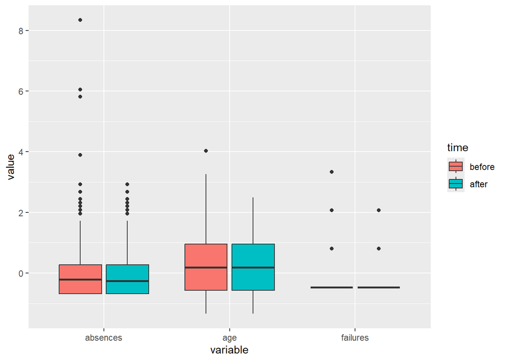

```r
# replacing outliers with NA
train_wo_outliers <- train_norm %>% mutate(across(c("age", "failures", "absences"), ~ ifelse(outliers[[cur_column()]], NA, .)))

# creating data plot for plotting
before_after <- data.frame(
    age_before = z_scores$age,
    age_after = train_wo_outliers$age,
    absences_before = z_scores$absences,
    absences_after = train_wo_outliers$absences,
    failures_before = z_scores$failures,
    failures_after = train_wo_outliers$failures
)

# long format for boxplots
before_after <- before_after %>% pivot_longer(
  cols = everything(),
  names_to = c("variable", "time"),
  names_sep = "_",
  values_to = "value"
) %>%
  mutate(time = factor(time, levels = c("before", "after")))

# Before after plot
ggplot(before_after, aes(x=variable, y=value, fill=time)) +
  geom_boxplot()
```

```r
# Removing NA rows from the dataset (actually removing the outliers)
cat("Rows containing outliers:", sum(!complete.cases(train_wo_outliers)), "\n")
```

```
Rows containing outliers: 20
```

```r
train_wo_outliers <- na.omit(train_wo_outliers)
cat("Remaining rows:", nrow(train_wo_outliers), "\n")
```

```
Remaining rows: 296
```

### One-hot-encoding for categorical values

Deep learning can only handle numerical values, so we need to create a one-hot encoding for all categorical variables.

```r
nominal_vars <- c("Mjob","Fjob","reason","guardian")

train_one_hot <- dummy_cols(
  train_norm,
  select_columns = nominal_vars,
  remove_selected_columns = TRUE
)
```

We also need to convert binary factors to 0 or 1.

```r
binary_vars <- c("school","sex","address", "famsize", "Pstatus")

# assigning TRUE or FALSE to binary values (the second possible value is assigned 1 the first 0)
train_one_hot <- train_one_hot %>% mutate(across(all_of(binary_vars), ~ as.integer(.x == levels(.x)[2])))
```

### Train test split

We need to split the train dataset to a sample used for training, a sample used for validation during training and a test sample to check performance after the training is done. We have decided to split the train data 80:10:10 (training: validation: testing)

```r
# set seed for reproducibility
set.seed(123)

#first split the full data set in a 80/20 test train set then split the test val data 50/50 so they both become 10% of the full dataset
train_split <- sample.split(train$score, SplitRatio = 0.8)
val_split <- sample.split(train$score[!train_split], SplitRatio = 0.5)

# save the row indices that are part of the set
train_ids <- which(train_split)
temp_ids <- which(!train_split)
val_ids <- temp_ids[val_split]
test_ids <- temp_ids[!val_split]

# dataset for k-nearest neighbors and linear regression (normalized)
train_set <- train_norm[train_ids, ]
test_set <- train_norm[test_ids, ]
val_set <- train_norm[val_ids, ]

# dataset for deep learning (normalized & one-hot encoded)
train_deep <- train_one_hot[train_ids, ]
test_deep <- train_one_hot[test_ids, ]
val_deep <- train_one_hot[val_ids, ]
```

# Model description

A linear regression model is a parametric method that assumes a linear relationship between the feature variables and the target variable; “score”. This means that it estimates the impact of each variable on the score by giving all variables a coefficient, that determines if a variable impacts the score and how it impacts it. After we train the model on the train data, these coefficients are then used to make predictions on the test dataset.

## Linear regression

```r
#Creating the model
lin_regression <- lm(score ~ ., data = train_set)

#Check the performance of the model
summary(lin_regression)
```

```
Call:
lm(formula = score ~ ., data = train_set)

Residuals:
     Min       1Q   Median       3Q      Max
-2.66061 -0.57460  0.03332  0.58236  1.79477

Coefficients:
                  Estimate Std. Error t value Pr(>|t|)
(Intercept)       0.372829   0.540996   0.689  0.49148
schoolMS          0.105817   0.212146   0.499  0.61844
sexM              0.423032   0.137542   3.076  0.00238 **
age              -0.152789   0.074129  -2.061  0.04051 *
addressR         -0.173227   0.167652  -1.033  0.30266
famsizeLE3       -0.020024   0.131126  -0.153  0.87877
PstatusT         -0.012311   0.195227  -0.063  0.94978
Medu              0.443692   0.345623   1.284  0.20063
Fedu              0.027510   0.306306   0.090  0.92852
Mjobhealth        0.120541   0.296403   0.407  0.68465
Mjobother        -0.224146   0.190295  -1.178  0.24016
Mjobservices      0.050428   0.216519   0.233  0.81606
Mjobteacher      -0.467924   0.296516  -1.578  0.11604
Fjobother        -0.403390   0.265036  -1.522  0.12949
Fjobservices     -0.266231   0.265196  -1.004  0.31657
Fjobhealth       -0.162878   0.362293  -0.450  0.65348
Fjobat_home      -0.271374   0.345309  -0.786  0.43281
reasonother       0.183735   0.218783   0.840  0.40196
reasonhome        0.082250   0.150384   0.547  0.58500
reasonreputation  0.093038   0.159498   0.583  0.56030
guardianfather   -0.093095   0.145131  -0.641  0.52192
guardianother     0.254779   0.226045   1.127  0.26097
traveltime        0.079425   0.326502   0.243  0.80804
studytime         0.429814   0.226312   1.899  0.05889 .
failures         -0.347355   0.072124  -4.816 2.78e-06 ***
schoolsupTRUE    -0.516066   0.173300  -2.978  0.00324 **
famsupTRUE       -0.179286   0.133760  -1.340  0.18156
paidTRUE         -0.002611   0.134449  -0.019  0.98453
activitiesTRUE   -0.089598   0.123288  -0.727  0.46819
nurseryTRUE       0.052027   0.144815   0.359  0.71975
higherTRUE        0.093855   0.271117   0.346  0.72955
internetTRUE     -0.042564   0.163487  -0.260  0.79485
romanticTRUE     -0.241804   0.128387  -1.883  0.06101 .
famrel           -0.051045   0.280210  -0.182  0.85562
freetime          0.168869   0.273902   0.617  0.53821
goout            -0.759580   0.266374  -2.852  0.00478 **
Dalc              0.189136   0.380823   0.497  0.61995
Walc             -0.046492   0.285010  -0.163  0.87057
health           -0.122336   0.176606  -0.693  0.48925
absences          0.049814   0.061195   0.814  0.41655
---
Signif. codes:  0 '***' 0.001 '**' 0.01 '*' 0.05 '.' 0.1 ' ' 1

Residual standard error: 0.8726 on 212 degrees of freedom
Multiple R-squared:  0.3542,    Adjusted R-squared:  0.2354
F-statistic: 2.982 on 39 and 212 DF,  p-value: 2.59e-07
```

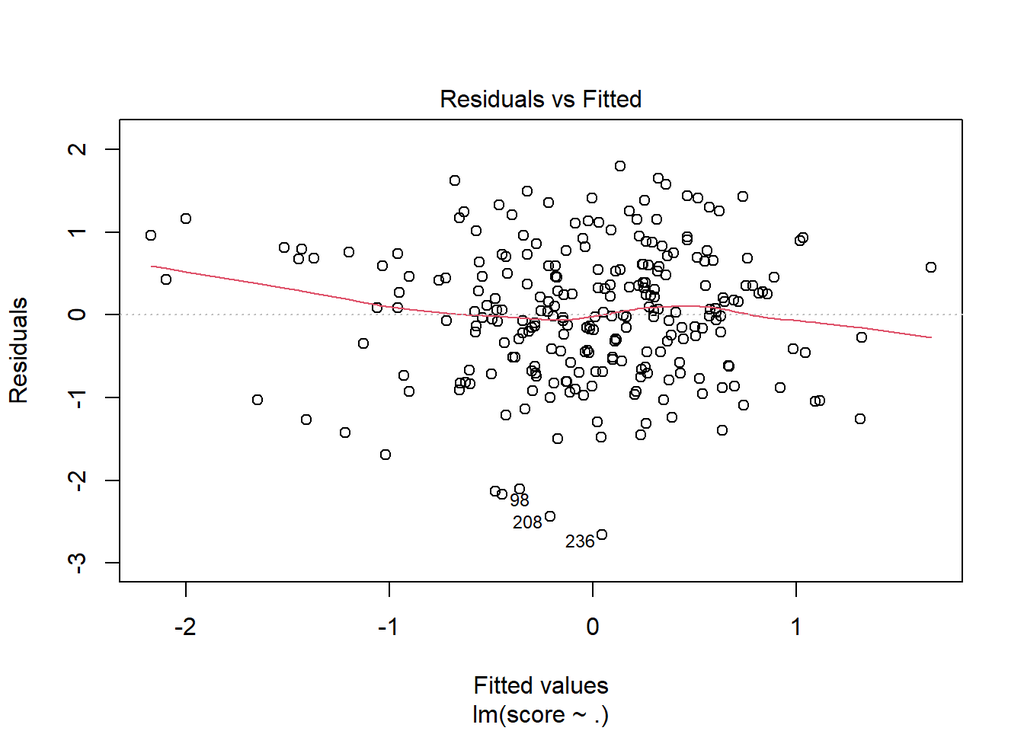

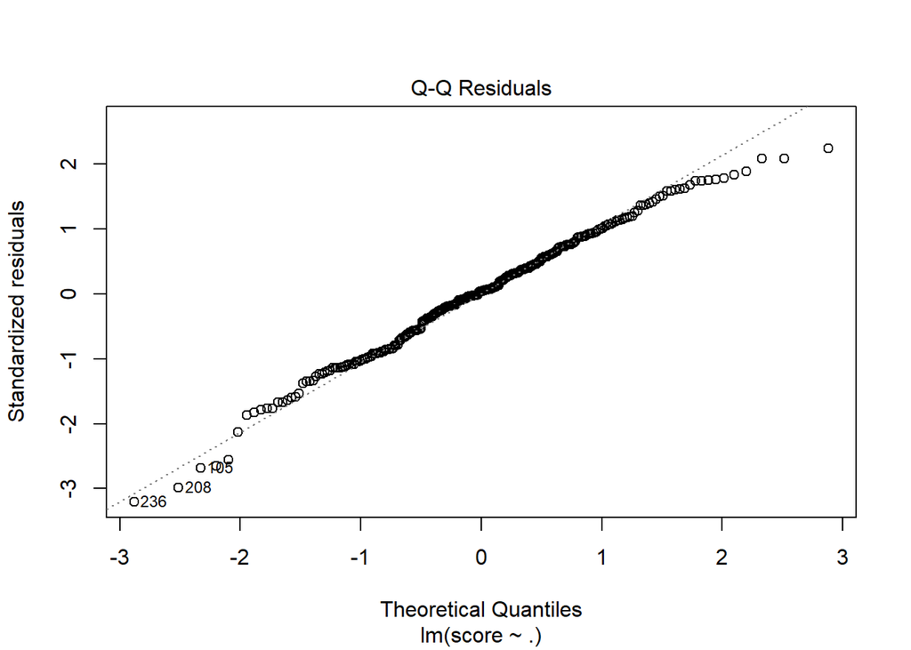

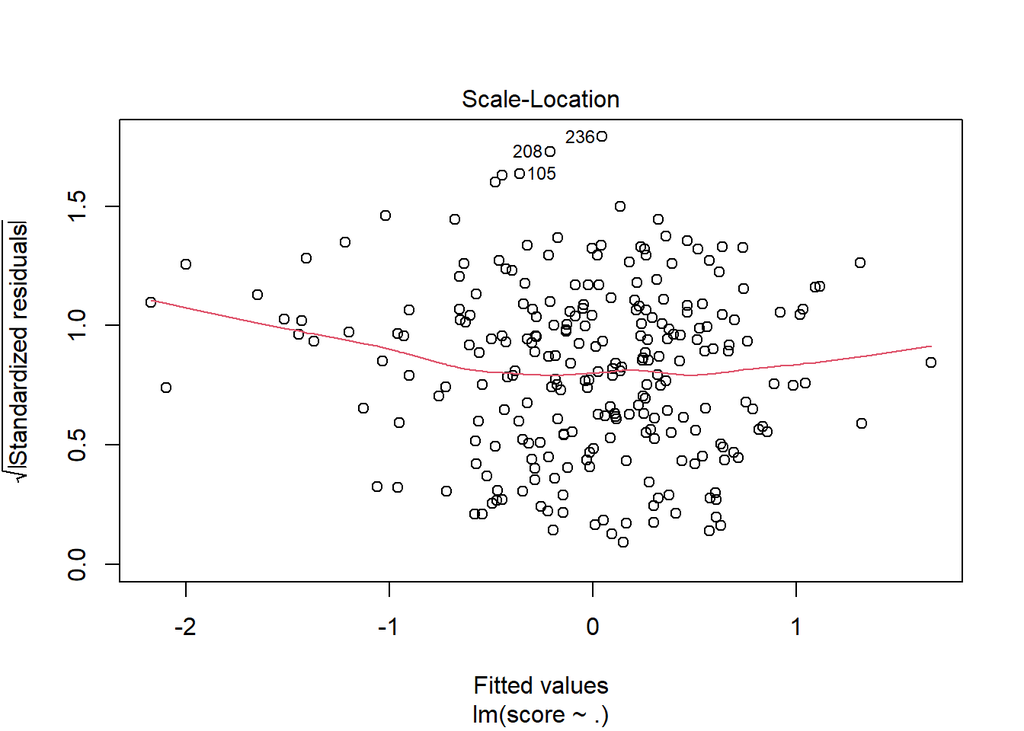

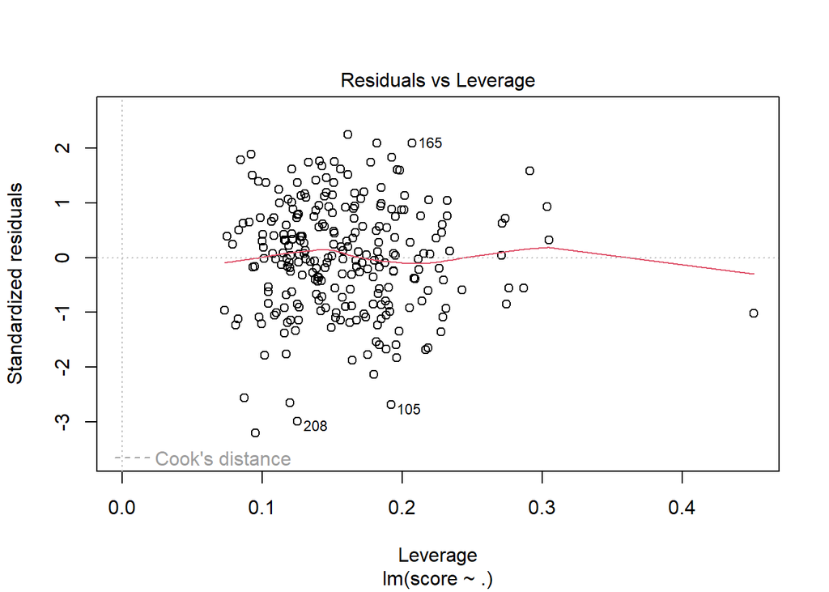

```r
plot(lin_regression)
```

```r
#calculate the MSE for the linear model
predictions_linear <- predict(lin_regression, newdata = test_set)
true_score <- test_set$score

lin_reg_mse <- mean((true_score- predictions_linear)^2)
print(lin_reg_mse)
```

```
[1] 0.8916563
```

The fitted model explains approximately 35.5% of the variance in student scores, indicating that at least one of the predictors contributes to explaining variation in the dependent variable.

### Assumption Checking

1. Residuals vs Fitted

The residuals appear randomly scattered around zero with no clear pattern, this means that the linearity assumption is met. The slight curvature in the red trend line is minor and does not indicate strong nonlinearity.

2. Q–Q Plot

The residuals fall closely along the 45° reference line, implying that the normality assumption of residuals is reasonably satisfied. A few mild deviations at the tails are visible but not severe enough to threaten inference validity.

3. Scale–Location Plot

The spread of residuals is roughly constant across fitted values, supporting the homoscedasticity assumption (equal variance of errors).There is no strong funnel shape,

4. Residuals vs Leverage

Most data points fall within the Cook’s distance boundaries, meaning no highly influential observations that affect model estimates. A few points show slightly higher leverage but remain within acceptable limits.

### Checking for Multicollinearity

To assess multicollinearity among the independent variables, the Variance Inflation Factor (VIF) was computed using the `car::vif()` function. The Generalized VIF (GVIF) and its adjusted value `GVIF^(1/(2*Df))` were examined to identify any predictors exhibiting high multicollinearity.

| Threshold | Interpretation |
| --- | --- |
| < 2 | Low multicollinearity (ideal) |
| 2–5 | Moderate multicollinearity (acceptable) |
| > 5 | High multicollinearity (problematic) |

```r
# Check VIF values
vif(lin_regression)
```

```
               GVIF Df GVIF^(1/(2*Df))
school     1.562287  1        1.249915
sex        1.540170  1        1.241036
age        1.907480  1        1.381115
address    1.587322  1        1.259890
famsize    1.161444  1        1.077703
Pstatus    1.206828  1        1.098557
Medu       3.015164  1        1.736423
Fedu       2.344749  1        1.531257
Mjob       4.014552  4        1.189747
Fjob       2.779341  4        1.136299
reason     1.834243  3        1.106393
guardian   1.827052  2        1.162620
traveltime 1.343147  1        1.158942
studytime  1.362247  1        1.167153
failures   1.645054  1        1.282597
schoolsup  1.245244  1        1.115905
famsup     1.390894  1        1.179362
paid       1.471688  1        1.213131
activities 1.257698  1        1.121471
nursery    1.184328  1        1.088268
higher     1.446647  1        1.202767
internet   1.385729  1        1.177170
romantic   1.174176  1        1.083594
famrel     1.215133  1        1.102331
freetime   1.453943  1        1.205796
goout      1.702763  1        1.304899
Dalc       2.121808  1        1.456643
Walc       2.645007  1        1.626348
health     1.236427  1        1.111947
absences   1.243783  1        1.115250
```

```r
vif_values <- vif(lin_regression)
high_vif <- vif_values[vif_values[, "GVIF"] > 5, ]
high_vif
```

```
     GVIF Df GVIF^(1/(2*Df))
```

There are no highly influential points, all fall under the 5 threshold, so there is no need to remove a predictor and to rebuild the model with new data

## KNN-regression

The KNN regression is a non-parametric model which makes predictions based on what the closest neighbours are doing. Usually we pick K=5 and K=10, where K is the number of neighors considered. As a result, if we want to predict the score with the KNN regression model, we need to find the K most similar students and then take the average of the scores. The model we used will check all the possible K values with the maximum K equal to 10, and then it will return the predictions with the best K. For our data the best K is 10.

```r
#KNN regression without the outliers
model_1 <- train.kknn(
  score ~ .,
  data = train_set,
  kmax = 10,
  distance = 2,
  kernel = "optimal"
)

model_1
```

```
Call:
train.kknn(formula = score ~ ., data = train_set, kmax = 10,     distance = 2, kernel = "optimal")

Type of response variable: continuous
minimal mean absolute error: 0.7497548
Minimal mean squared error: 0.9171479
Best kernel: optimal
Best k: 10
```

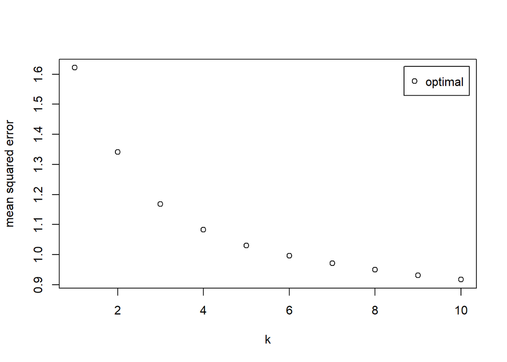

```r
plot(model_1)
```

```r
predictions_knn <- predict(model_1, newdata = test_set)


#KNN regression with the outliers
model_2 <- train.kknn(
  score ~ .,
  data = train_wo_outliers,
  kmax = 10,
  distance = 2,
  kernel = "optimal"
)

model_2
```

```
Call:
train.kknn(formula = score ~ ., data = train_wo_outliers, kmax = 10,     distance = 2, kernel = "optimal")

Type of response variable: continuous
minimal mean absolute error: 0.7624276
Minimal mean squared error: 0.9432617
Best kernel: optimal
Best k: 10
```

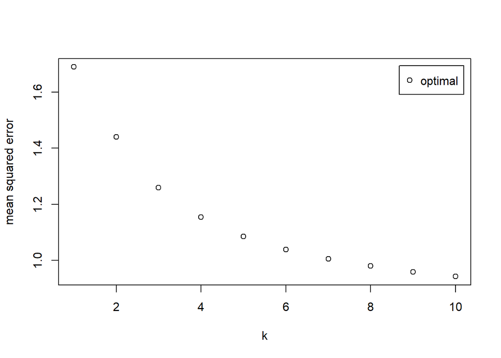

```r
plot(model_2)
```

```r
pred_wo_outliers <- predict(model_2, newdata = test)

#Check the impact of outliers
differences <- predictions_knn - pred_wo_outliers
summary(differences)
```

```
   Min. 1st Qu.  Median    Mean 3rd Qu.    Max.
-1.2002  0.1345  0.4292  0.4254  0.6795  1.6698
```